# Praktikum Visi Komputer

### Bagaimana kita mendefinisikan "menarik"?

Sebelum menghitung *seam*, kita perlu menemukan metrik yang dapat digunakan untuk menghitung *seam*. Kita perlu cara untuk memberi nilai "penting" ke setiap piksel sehingga kita dapat menemukan jalur yang kurang penting. Dalam istilah visi komputer, kita perlu memberi nilai energi untuk setiap piksel sehingga kita dapat menemukan jalur dari energi minimum. Jadi menemukan cara yang bagus untuk memberi nilai energi menjadi sangat penting karena hal ini akan memberi efek pada kualitas dari output.

Salah satu metrik yang dapat digunakan adalah nilai turunan (*derivative*) pada setiap titik. Ini merupakan indikator yang menentukan level aktivitas dalam lingkungan (*neighborhood*) tertentu. Jika ada aktivitas tertentu, maka nilai piksel akan berubah sangat jauh bedanya. Maka nilai turunan pada titik tersebut menjadi tinggi. Sebaliknya, jika suatu bagian polos dan tidak menarik, maka nilai piksel tidak akan terlalu jauh bedanya. Maka nilai turunan pada titik tersebut akan rendah.

Untuk setiap lokasi piksel, kita hitung energi dengan menjumlahkan turunan dari X dan Y pada titik tersebut. Kita menghitung turunan dengan menghitung perbedaan antara piksel sekarang dan piksel tetangganya. Proses ini telah dipelajari pada prak3 di mana kita mendeteksi tepi dan mengaplikasikan filter pada citra. Proses tersebut akan memanfaatkan matriks operasi Convolution. Nilai yang telah dihitung disimpan dalam matriks energi.

[figure not shown]

Sesudah kita punya matriks energi. maka kita dapat mulai menghitung *seam*. Kita perlu menemukan jalur pada citra yang memiliki energi paling rendah. Namun mencari semua jalur yang mungkin adalah *expensive* sebab perlu dimulai dari baris pertama hingga baris terakhir. Solusinya dengan memanfaatkan *dynamic programming*.

Untuk setiap piksel pada baris sekarang, kita hitung energi dari 3 lokasi piksel yang mungkin untuk pindah pada baris berikutnya (yaitu bawah kiri, bawah, bawah kanan).Proses ini akan terus berulang hingga mencapai baris paling bawah. Pada baris paling bawah, akan dilihat mana nilai kumulatif yang paling kecil lalu kita melakukan proses backtrack ke atas. Proses ini akan menghasilkan jalur dari energi yang paling kecil. Setiap satu *seam* dihapus maka lebar citra akan berkurang sebanyak 1. Jadi kita perlu menghapus *seam* hingga mencapai ukuran yang diinginkan.

```python
# Mengubah ukuran lebar citra dengan metode seam carving
import sys
import cv2
import numpy as np
from past.builtins import xrange #xrange is imported from pastbuilt

# Draw vertical seam on top of the image
def overlay_vertical_seam(img, seam):
    img_seam_overlay = np.copy(img)

    # Extract the list of points from the seam
    x_coords, y_coords = np.transpose([(i,int(j)) for i,j in enumerate(seam)])

    # Draw a blue line on the image using the list of points
    img_seam_overlay[x_coords, y_coords] = (255,0,0)
    return img_seam_overlay

# Compute the energy matrix from the input image
def compute_energy_matrix(img):
    gray = cv2.cvtColor(img, cv2.COLOR_BGR2GRAY)

    # Compute X derivative of the image
    sobel_x = cv2.Sobel(gray,cv2.CV_64F,1,0,ksize=3)

    # Compute Y derivative of the image
    sobel_y = cv2.Sobel(gray,cv2.CV_64F,0,1,ksize=3)

    abs_sobel_x = cv2.convertScaleAbs(sobel_x)
    abs_sobel_y = cv2.convertScaleAbs(sobel_y)

    # Return weighted summation of the two images i.e. 0.5*X + 0.5*Y
    return cv2.addWeighted(abs_sobel_x, 0.5, abs_sobel_y, 0.5, 0)

# Find vertical seam in the input image
def find_vertical_seam(img, energy):
    rows, cols = img.shape[:2]

    # Initialize the seam vector with 0 for each element
    seam = np.zeros(img.shape[0])

    # Initialize distance and edge matrices
    dist_to = np.zeros(img.shape[:2]) + sys.maxsize
    dist_to[0,:] = np.zeros(img.shape[1])
    edge_to = np.zeros(img.shape[:2])

    # Dynamic programming; iterate using double loop and compute the paths efficiently
    for row in xrange(rows-1):
        for col in xrange(cols):
            if col != 0:
                if dist_to[row+1, col-1] > dist_to[row, col] + energy[row+1, col-1]:
                    dist_to[row+1, col-1] = dist_to[row, col] + energy[row+1, col-1]
                    edge_to[row+1, col-1] = 1

            if dist_to[row+1, col] > dist_to[row, col] + energy[row+1, col]:
                dist_to[row+1, col] = dist_to[row, col] + energy[row+1, col]
                edge_to[row+1, col] = 0

            if col != cols-1:
                if dist_to[row+1, col+1] > dist_to[row, col] + energy[row+1, col+1]:
                    dist_to[row+1, col+1] = dist_to[row, col] + energy[row+1, col+1]
                    edge_to[row+1, col+1] = -1

    # Retracing the path
    seam[rows-1] = np.argmin(dist_to[rows-1, :])
    for i in (x for x in reversed(xrange(rows)) if x > 0):
        seam[i-1] = seam[i] + edge_to[i, int(seam[i])]

    return seam

# Remove the input vertical seam from the image
def remove_vertical_seam(img, seam):
    rows, cols = img.shape[:2]

    # To delete a point, move every point after it one step towards the left
    for row in xrange(rows):
        for col in xrange(int(seam[row]), cols-1):
            img[row, col] = img[row, col+1]

    # Discard the last column to create the final output image
    img = img[:, 0:cols-1]
    return img

if __name__=='__main__':
    # Make sure the size of the input image is reasonable.
    # Large images take a lot of time to be processed.
    # Recommended size is 640x480.
    img_input = cv2.imread('Prak8/gambar/duck1.jpg')

    # boleh juga mencoba gambar lain lagi seperti https://i.im.ge/2021/10/20/o2A2Vr.png
    # gambar ini lebih kecil sehingga proses lebih cepat

    # Use a small number to get started. Once you get an
    # idea of the processing time, you can use a bigger number.
    # To get started, you can set it to 20.
    num_seams = int(20)

    img = np.copy(img_input)
    img_overlay_seam = np.copy(img_input)
    energy = compute_energy_matrix(img)

    for i in xrange(num_seams):
        seam = find_vertical_seam(img, energy)
        img_overlay_seam = overlay_vertical_seam(img_overlay_seam, seam)
        img = remove_vertical_seam(img, seam)
        energy = compute_energy_matrix(img)
        print ('Number of seams removed =', i+1)

    cv2.imshow('Input', img_input)
    cv2.imshow('Seams', img_overlay_seam)
    cv2.imshow('Output', img)
    cv2.waitKey()
```

```
Number of seams removed = 1
Number of seams removed = 2
Number of seams removed = 3
Number of seams removed = 4
Number of seams removed = 5
Number of seams removed = 6
Number of seams removed = 7
Number of seams removed = 8
Number of seams removed = 9
Number of seams removed = 10
Number of seams removed = 11
Number of seams removed = 12
Number of seams removed = 13
Number of seams removed = 14
Number of seams removed = 15
Number of seams removed = 16
Number of seams removed = 17
Number of seams removed = 18
Number of seams removed = 19
Number of seams removed = 20
```

### Memperbesar citra

Kita telah mencoba contoh di atas dan kita tahu bahwa kita dapat mengurangi lebar dari gambar tanpa merusak bagian menarik pada citra. Apakah mungkin kita dapat memperbesar citra tanpa merusak bagian menarik pada citra?

Jawabannya adalah bisa. Kita dapat menggunakan logika yang sama. Namun saat kita menghitung seam, kita menambahkan kolom ekstra, bukan menghapusnya.

Jika kita memperbesar citra dengan menggunakan resize, maka bagian menarik menjadi tidak simetris.

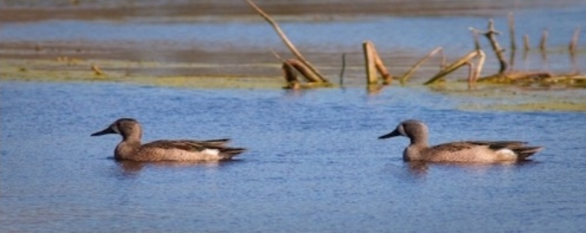

Namun jika gunakan cara yang lebih *smart* dengan menggunakan *seam carving* maka hasilnya menjadi:

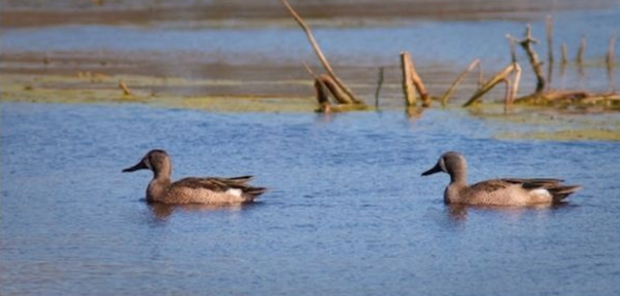

```python
# Kode yang sama dengan sebelumnya, hanya di sini ditambahkan
# fungsi add_vertical_seam

import sys
import cv2
import numpy as np
from past.builtins import xrange #xrange is imported from pastbuilt

# Draw vertical seam on top of the image
def overlay_vertical_seam(img, seam):
    img_seam_overlay = np.copy(img)

    # Extract the list of points from the seam
    x_coords, y_coords = np.transpose([(i,int(j)) for i,j in enumerate(seam)])

    # Draw a blue line on the image using the list of points
    img_seam_overlay[x_coords, y_coords] = (255,0,0)
    return img_seam_overlay

# Compute the energy matrix from the input image
def compute_energy_matrix(img):
    gray = cv2.cvtColor(img, cv2.COLOR_BGR2GRAY)

    # Compute X derivative of the image
    sobel_x = cv2.Sobel(gray,cv2.CV_64F,1,0,ksize=3)

    # Compute Y derivative of the image
    sobel_y = cv2.Sobel(gray,cv2.CV_64F,0,1,ksize=3)

    abs_sobel_x = cv2.convertScaleAbs(sobel_x)
    abs_sobel_y = cv2.convertScaleAbs(sobel_y)

    # Return weighted summation of the two images i.e. 0.5*X + 0.5*Y
    return cv2.addWeighted(abs_sobel_x, 0.5, abs_sobel_y, 0.5, 0)

# Find vertical seam in the input image
def find_vertical_seam(img, energy):
    rows, cols = img.shape[:2]

    # Initialize the seam vector with 0 for each element
    seam = np.zeros(img.shape[0])

    # Initialize distance and edge matrices
    dist_to = np.zeros(img.shape[:2]) + sys.maxsize
    dist_to[0,:] = np.zeros(img.shape[1])
    edge_to = np.zeros(img.shape[:2])

    # Dynamic programming; iterate using double loop and compute the paths efficiently
    for row in xrange(rows-1):
        for col in xrange(cols):
            if col != 0:
                if dist_to[row+1, col-1] > dist_to[row, col] + energy[row+1, col-1]:
                    dist_to[row+1, col-1] = dist_to[row, col] + energy[row+1, col-1]
                    edge_to[row+1, col-1] = 1

            if dist_to[row+1, col] > dist_to[row, col] + energy[row+1, col]:
                dist_to[row+1, col] = dist_to[row, col] + energy[row+1, col]
                edge_to[row+1, col] = 0

            if col != cols-1:
                if dist_to[row+1, col+1] > dist_to[row, col] + energy[row+1, col+1]:
                    dist_to[row+1, col+1] = dist_to[row, col] + energy[row+1, col+1]
                    edge_to[row+1, col+1] = -1

    # Retracing the path
    seam[rows-1] = np.argmin(dist_to[rows-1, :])
    for i in (x for x in reversed(xrange(rows)) if x > 0):
        seam[i-1] = seam[i] + edge_to[i, int(seam[i])]

    return seam

# Remove the input vertical seam from the image
def remove_vertical_seam(img, seam):
    rows, cols = img.shape[:2]

    # To delete a point, move every point after it one step towards the left
    for row in xrange(rows):
        for col in xrange(int(seam[row]), cols-1):
            img[row, col] = img[row, col+1]

    # Discard the last column to create the final output image
    img = img[:, 0:cols-1]
    return img

# Add a vertical seam to the image
def add_vertical_seam(img, seam, num_iter):
    seam = seam + num_iter
    rows, cols = img.shape[:2]
    zero_col_mat = np.zeros((rows,1,3), dtype=np.uint8)
    img_extended = np.hstack((img, zero_col_mat))

    for row in xrange(rows):
        for col in xrange(cols, int(seam[row]), -1):
            img_extended[row, col] = img[row, col-1]

        # To insert a value between two columns, take the average
        # value of the neighbors. It looks smooth this way and we
        # can avoid unwanted artifacts.
        for i in range(3):
            v1 = img_extended[row, int(seam[row])-1, i]
            v2 = img_extended[row, int(seam[row])+1, i]
            img_extended[row, int(seam[row]), i] = (int(v1)+int(v2))/2

    return img_extended

if __name__=='__main__':
    img_input = cv2.imread("Prak8/gambar/duck1.jpg")
    num_seams = int(20)
    img = np.copy(img_input)
    img_output = np.copy(img_input)
    energy = compute_energy_matrix(img)

    for i in xrange(num_seams):
        seam = find_vertical_seam(img, energy)
        img = remove_vertical_seam(img, seam)
        img_output = add_vertical_seam(img_output, seam, i)
        energy = compute_energy_matrix(img)
        print ('Number of seams added =', i+1)

    cv2.imshow('Input', img_input)
    cv2.imshow('Output', img_output)
    cv2.waitKey()
```

```
Number of seams added = 1
Number of seams added = 2
Number of seams added = 3
Number of seams added = 4
Number of seams added = 5
Number of seams added = 6
Number of seams added = 7
Number of seams added = 8
Number of seams added = 9
Number of seams added = 10
Number of seams added = 11
Number of seams added = 12
Number of seams added = 13
Number of seams added = 14
Number of seams added = 15
Number of seams added = 16
Number of seams added = 17
Number of seams added = 18
Number of seams added = 19
Number of seams added = 20
```

### Menghapus objek pada citra

Proses menghapus objek dari citra merupakan bagian paling menarik pada *seam carving*. Kita dapat membuat objek hilang sama sekali pada suatu citra.

```python
# Program yang relatif sama dengan sebelumnya,
# hanya menambahkan pemilihan objek yang akan dihapus
import sys
import cv2
import numpy as np
from past.builtins import xrange #xrange is imported from pastbuilt

# Draw rectangle on top of the input image
def draw_rectangle(event, x, y, flags, params):
    global x_init, y_init, drawing, top_left_pt, bottom_right_pt, img_orig

    # Detecting a mouse click
    if event == cv2.EVENT_LBUTTONDOWN:
        drawing = True
        x_init, y_init = x, y

    # Detecting mouse movement
    elif event == cv2.EVENT_MOUSEMOVE:
        if drawing:
            top_left_pt, bottom_right_pt = (x_init,y_init), (x,y)
            img[y_init:y, x_init:x] = 255 - img_orig[y_init:y, x_init:x]
            cv2.rectangle(img, top_left_pt, bottom_right_pt, (0,255,0), 2)

    # Detecting the mouse button up event
    elif event == cv2.EVENT_LBUTTONUP:
        drawing = False
        top_left_pt, bottom_right_pt = (x_init,y_init), (x,y)

        # Create the "negative" film effect for the selected # region
        img[y_init:y, x_init:x] = 255 - img[y_init:y, x_init:x]

        # Draw rectangle around the selected region
        cv2.rectangle(img, top_left_pt, bottom_right_pt, (0,255,0), 2)
        rect_final = (x_init, y_init, x-x_init, y-y_init)

        # Remove the object in the selected region
        remove_object(img_orig, rect_final)

# Computing the energy matrix using modified algorithm
def compute_energy_matrix_modified(img, rect_roi):
    gray = cv2.cvtColor(img, cv2.COLOR_BGR2GRAY)

    # Compute the X derivative
    sobel_x = cv2.Sobel(gray,cv2.CV_64F,1,0,ksize=3)

    # Compute the Y derivative
    sobel_y = cv2.Sobel(gray,cv2.CV_64F,0,1,ksize=3)

    abs_sobel_x = cv2.convertScaleAbs(sobel_x)
    abs_sobel_y = cv2.convertScaleAbs(sobel_y)

    # Compute weighted summation i.e. 0.5*X + 0.5*Y
    energy_matrix = cv2.addWeighted(abs_sobel_x, 0.5, abs_sobel_y, 0.5, 0)
    x,y,w,h = rect_roi

    # We want the seams to pass through this region, so make sure the
    # energy values in this region are set to 0
    energy_matrix[y:y+h, x:x+w] = 0

    return energy_matrix

# Compute the energy matrix from the input image
def compute_energy_matrix(img):
    gray = cv2.cvtColor(img, cv2.COLOR_BGR2GRAY)

    # Compute X derivative of the image
    sobel_x = cv2.Sobel(gray,cv2.CV_64F,1,0,ksize=3)

    # Compute Y derivative of the image
    sobel_y = cv2.Sobel(gray,cv2.CV_64F,0,1,ksize=3)

    abs_sobel_x = cv2.convertScaleAbs(sobel_x)
    abs_sobel_y = cv2.convertScaleAbs(sobel_y)

    # Return weighted summation of the two images i.e. 0.5*X + 0.5*Y
    return cv2.addWeighted(abs_sobel_x, 0.5, abs_sobel_y, 0.5, 0)

# Find vertical seam in the input image
def find_vertical_seam(img, energy):
    rows, cols = img.shape[:2]

    # Initialize the seam vector with 0 for each element
    seam = np.zeros(img.shape[0])

    # Initialize distance and edge matrices
    dist_to = np.zeros(img.shape[:2]) + sys.maxsize
    dist_to[0,:] = np.zeros(img.shape[1])
    edge_to = np.zeros(img.shape[:2])

    # Dynamic programming; iterate using double loop and compute the paths efficiently
    for row in xrange(rows-1):
        for col in xrange(cols):
            if col != 0:
                if dist_to[row+1, col-1] > dist_to[row, col] + energy[row+1, col-1]:
                    dist_to[row+1, col-1] = dist_to[row, col] + energy[row+1, col-1]
                    edge_to[row+1, col-1] = 1

            if dist_to[row+1, col] > dist_to[row, col] + energy[row+1, col]:
                dist_to[row+1, col] = dist_to[row, col] + energy[row+1, col]
                edge_to[row+1, col] = 0

            if col != cols-1:
                if dist_to[row+1, col+1] > dist_to[row, col] + energy[row+1, col+1]:
                    dist_to[row+1, col+1] = dist_to[row, col] + energy[row+1, col+1]
                    edge_to[row+1, col+1] = -1

    # Retracing the path
    seam[rows-1] = np.argmin(dist_to[rows-1, :])
    for i in (x for x in reversed(xrange(rows)) if x > 0):
        seam[i-1] = seam[i] + edge_to[i, int(seam[i])]

    return seam

# Remove the input vertical seam from the image
def remove_vertical_seam(img, seam):
    rows, cols = img.shape[:2]

    # To delete a point, move every point after it one step towards the left
    for row in xrange(rows):
        for col in xrange(int(seam[row]), cols-1):
            img[row, col] = img[row, col+1]

    # Discard the last column to create the final output image
    img = img[:, 0:cols-1]
    return img

# Add a vertical seam to the image
def add_vertical_seam(img, seam, num_iter):
    seam = seam + num_iter
    rows, cols = img.shape[:2]
    zero_col_mat = np.zeros((rows,1,3), dtype=np.uint8)
    img_extended = np.hstack((img, zero_col_mat))

    for row in xrange(rows):
        for col in xrange(cols, int(seam[row]), -1):
            img_extended[row, col] = img[row, col-1]

        # To insert a value between two columns, take the average
        # value of the neighbors. It looks smooth this way and we
        # can avoid unwanted artifacts.
        for i in range(3):
            v1 = img_extended[row, int(seam[row])-1, i]
            v2 = img_extended[row, int(seam[row])+1, i]
            img_extended[row, int(seam[row]), i] = (int(v1)+int(v2))/2

    return img_extended

# Remove the object from the input region of interest
def remove_object(img, rect_roi):
    num_seams = rect_roi[2] + 10
    energy = compute_energy_matrix_modified(img, rect_roi)

    # Start a loop and remove one seam at a time
    for i in xrange(num_seams):
        # Find the vertical seam that can be removed
        seam = find_vertical_seam(img, energy)

        # Remove that vertical seam
        img = remove_vertical_seam(img, seam)
        x,y,w,h = rect_roi

        # Compute energy matrix after removing the seam
        energy = compute_energy_matrix_modified(img, (x,y,w-i,h))
        print ('Number of seams removed =', i+1)

    img_output = np.copy(img)

    # Fill up the region with surrounding values so that the size # of the
    # image remains unchanged
    for i in xrange(num_seams):
        seam = find_vertical_seam(img, energy)
        img = remove_vertical_seam(img, seam)
        img_output = add_vertical_seam(img_output, seam, i)
        energy = compute_energy_matrix(img)
        print ('Number of seams added =', i+1)

    cv2.imshow('Input', img_input)
    cv2.imshow('Output', img_output)
    cv2.waitKey()

if __name__=='__main__':
    img_input = cv2.imread("Prak8/gambar/duck1.jpg")

    drawing = False
    img = np.copy(img_input)
    img_orig = np.copy(img_input)

    cv2.namedWindow('Input')
    cv2.setMouseCallback('Input', draw_rectangle)

    while True:
        cv2.imshow('Input', img)

        # The control breaks once q key is pressed
        if cv2.waitKey(1) & 0xff == ord('q'):
            break

    cv2.destroyAllWindows()
```

### Apakah itu segmentasi citra?

Segmentasi citra (*image segmentation*) merupakan proses pemisahan citra menjadi komponen-komponen penyusunnya. Segmentasi merupakan langkah penting dalam banyak aplikasi visi komputer. Ada banyak cara untuk melakukan segmentasi citra. Kita dapat melakukan segmentasi citra menggunakan metrik seperti warna, tekstur, lokasi dan lainnya. Semua piksel di dalam satu kawasan memiliki sesuatu yang sama bergantung pada metrik yang kita gunakan.

Di sini kita akan melihat teknik yang dinamakan **GrabCut**. Ini merupakan metode segmentasi berdasarkan metode **graph-cut**. Pada metode grab-cut, kita menganggap keseluruhan citra sebagai graf, lalu kita lakukan segmentasi graf berdasarkan kekuatan tepi pada graf tersebut. Kita membangun graf dengan mempertimbangkan setiap piksel menjadi node dan tepi dibangun di antara node, di mana berat tepi adalah fungsi nilai piksel dari dua node tersebut. Ketika ada tepi, nilai piksel menjadi lebih tinggi, sehingga berat tepi juga lebih tinggi. Graf ini lalu disegmentasi dengan meminimalkan energi Gibss pada graf. Atau disebut juga *maximum entropy segmentation*. Artikel aslinya dapat dibaca di http://cvg.ethz.ch/teaching/cvl/2012/grabcut-siggraph04.pdf.

Algoritma GrabCut algorithm:

- Terima citra input dengan kondisi (1) ada *bounding box* yang menspesifikkan lokasi objek pada citra yang ingin disegmentasi atau (2) ada *mask* yang memperkirakan segmentasi
- Secara berulang lakukan langkah berikut:
  1. Langkah 1: memperkirakan distribusi warna dari foreground dan background dengan Gaussian Mixture Model (GMM)
  2. Langkah 2: Membangun *Markov random field* terhadap label piksel (seperti foreground vs background). Artikel untuk langkah 1 & 2: http://research.microsoft.com/pubs/67898/eccv04-GMMRF.pdf
  3. Langkah 3: Mengaplikasikan optimisasi graph-cut untuk menghasilkan segmentasi terakhir

Terkesan rumit, namun OpenCV telah menyediakan fungsi `cv2.grabCut` yang dapat mempermudah pekerjaan segmentasi. Yang penting kita tahu cara menggunakan parameter-parameternya dan mengubahnya bila diperlukan.

```python
# Segmentasi dengan metode GrabCut
import cv2
import numpy as np

# Draw rectangle based on the input selection
def draw_rectangle(event, x, y, flags, params):
    global x_init, y_init, drawing, top_left_pt, bottom_right_pt, img_orig

    # Detecting mouse button down event
    if event == cv2.EVENT_LBUTTONDOWN:
        drawing = True
        x_init, y_init = x, y

    # Detecting mouse movement
    elif event == cv2.EVENT_MOUSEMOVE:
        if drawing:
            top_left_pt, bottom_right_pt = (x_init,y_init), (x,y)
            img[y_init:y, x_init:x] = 255 - img_orig[y_init:y, x_init:x]
            cv2.rectangle(img, top_left_pt, bottom_right_pt, (0,255,0), 2)

    # Detecting mouse button up event
    elif event == cv2.EVENT_LBUTTONUP:
        drawing = False
        top_left_pt, bottom_right_pt = (x_init,y_init), (x,y)
        img[y_init:y, x_init:x] = 255 - img[y_init:y, x_init:x]
        cv2.rectangle(img, top_left_pt, bottom_right_pt, (0,255,0), 2)
        rect_final = (x_init, y_init, x-x_init, y-y_init)

        # Run Grabcut on the region of interest
        run_grabcut(img_orig, rect_final)

# Grabcut algorithm
def run_grabcut(img_orig, rect_final):
    # Initialize the mask
    mask = np.zeros(img_orig.shape[:2],np.uint8)

    # Extract the rectangle and set the region of
    # interest in the above mask
    x,y,w,h = rect_final
    mask[y:y+h, x:x+w] = 1

    # Initialize background and foreground models
    bgdModel = np.zeros((1,65), np.float64)
    fgdModel = np.zeros((1,65), np.float64)

    # Run Grabcut algorithm
    cv2.grabCut(img_orig, mask, rect_final, bgdModel, fgdModel, 5, cv2.GC_INIT_WITH_RECT)

    # Extract new mask
    mask2 = np.where((mask==2)|(mask==0),0,1).astype('uint8')

    # Apply the above mask to the image
    img_orig = img_orig*mask2[:,:,np.newaxis]

    # Display the image
    cv2.imshow('Output', img_orig)

if __name__=='__main__':
    drawing = False
    top_left_pt, bottom_right_pt = (-1,-1), (-1,-1)

    # Read the input image: https://i.im.ge/2021/10/21/oSciCz.jpg
    img_orig = cv2.imread("Prak8/gambar/butterfly.jpg")
    img = img_orig.copy()

    cv2.namedWindow('Input')
    cv2.setMouseCallback('Input', draw_rectangle)

    while True:
        cv2.imshow('Input', img)
        # The control breaks once q key is pressed
        if cv2.waitKey(1) & 0xff == ord('q'):
            break
    cv2.destroyAllWindows()
```

Dengan adanya perkembangan deep learning, terdapat metode segmentasi menggunakan deep learning yaitu *Faster R-CNN and U-Net*. Apakah ini bermakna GrabCut tidak relevan lagi untuk digunakan?

Sama sekali tidak. *Faster R-CNN and U-Net* memang dapat secara otomatis menghasilkan mask yang dapat mensegmentasi objek (foreground) dari background, namun hasilnya tidak rapi. Sehingga kita perlu menggunakan GrabCut untuk menghasilkan segmentasi objek yang lebih bagus dan rapi.

```
Number of seams added = 1
Number of seams added = 2
Number of seams added = 3
Number of seams added = 4
Number of seams added = 5
Number of seams added = 6
Number of seams added = 7
Number of seams added = 8
Number of seams added = 9
Number of seams added = 10
Number of seams added = 11
Number of seams added = 12
Number of seams added = 13
Number of seams added = 14
Number of seams added = 15
Number of seams added = 16
Number of seams added = 17
Number of seams added = 18
Number of seams added = 19
Number of seams added = 20
```

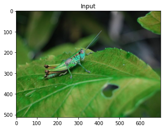

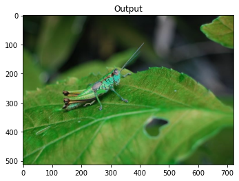

```python
# Latihan 1
# Ambil gambar dengan menggunakan kamera HP anda lalu upload ke situs https://im.ge/
# akses gambar tersebut langsung dengan menggunakan direct link yang diberikan
# lalu gunakan program seam carving untuk mengubah ukuran lebar dari gambar tersebut

import sys
import cv2
import numpy as np
import imutils
from past.builtins import xrange #xrange is imported from pastbuilt
from matplotlib import pyplot as plt

# Draw vertical seam on top of the image
def overlay_vertical_seam(img, seam):
    img_seam_overlay = np.copy(img)

    # Extract the list of points from the seam
    x_coords, y_coords = np.transpose([(i,int(j)) for i,j in enumerate(seam)])

    # Draw a blue line on the image using the list of points
    img_seam_overlay[x_coords, y_coords] = (255,0,0)
    return img_seam_overlay

# Compute the energy matrix from the input image
def compute_energy_matrix(img):
    gray = cv2.cvtColor(img, cv2.COLOR_BGR2GRAY)

    # Compute X derivative of the image
    sobel_x = cv2.Sobel(gray,cv2.CV_64F,1,0,ksize=3)

    # Compute Y derivative of the image
    sobel_y = cv2.Sobel(gray,cv2.CV_64F,0,1,ksize=3)

    abs_sobel_x = cv2.convertScaleAbs(sobel_x)
    abs_sobel_y = cv2.convertScaleAbs(sobel_y)

    # Return weighted summation of the two images i.e. 0.5*X + 0.5*Y
    return cv2.addWeighted(abs_sobel_x, 0.5, abs_sobel_y, 0.5, 0)

# Find vertical seam in the input image
def find_vertical_seam(img, energy):
    rows, cols = img.shape[:2]

    # Initialize the seam vector with 0 for each element
    seam = np.zeros(img.shape[0])

    # Initialize distance and edge matrices
    dist_to = np.zeros(img.shape[:2]) + sys.maxsize
    dist_to[0,:] = np.zeros(img.shape[1])
    edge_to = np.zeros(img.shape[:2])

    # Dynamic programming; iterate using double loop and compute the paths efficiently
    for row in xrange(rows-1):
        for col in xrange(cols):
            if col != 0:
                if dist_to[row+1, col-1] > dist_to[row, col] + energy[row+1, col-1]:
                    dist_to[row+1, col-1] = dist_to[row, col] + energy[row+1, col-1]
                    edge_to[row+1, col-1] = 1

            if dist_to[row+1, col] > dist_to[row, col] + energy[row+1, col]:
                dist_to[row+1, col] = dist_to[row, col] + energy[row+1, col]
                edge_to[row+1, col] = 0

            if col != cols-1:
                if dist_to[row+1, col+1] > dist_to[row, col] + energy[row+1, col+1]:
                    dist_to[row+1, col+1] = dist_to[row, col] + energy[row+1, col+1]
                    edge_to[row+1, col+1] = -1

    # Retracing the path
    seam[rows-1] = np.argmin(dist_to[rows-1, :])
    for i in (x for x in reversed(xrange(rows)) if x > 0):
        seam[i-1] = seam[i] + edge_to[i, int(seam[i])]

    return seam

# Remove the input vertical seam from the image
def remove_vertical_seam(img, seam):
    rows, cols = img.shape[:2]

    # To delete a point, move every point after it one step towards the left
    for row in xrange(rows):
        for col in xrange(int(seam[row]), cols-1):
            img[row, col] = img[row, col+1]

    # Discard the last column to create the final output image
    img = img[:, 0:cols-1]
    return img

# Add a vertical seam to the image
def add_vertical_seam(img, seam, num_iter):
    seam = seam + num_iter
    rows, cols = img.shape[:2]
    zero_col_mat = np.zeros((rows,1,3), dtype=np.uint8)
    img_extended = np.hstack((img, zero_col_mat))

    for row in xrange(rows):
        for col in xrange(cols, int(seam[row]), -1):
            img_extended[row, col] = img[row, col-1]

        # To insert a value between two columns, take the average
        # value of the neighbors. It looks smooth this way and we
        # can avoid unwanted artifacts.
        for i in range(3):
            v1 = img_extended[row, int(seam[row])-1, i]
            v2 = img_extended[row, int(seam[row])+1, i]
            img_extended[row, int(seam[row]), i] = (int(v1)+int(v2))/2

    return img_extended

if __name__=='__main__':
    img_input = imutils.url_to_image('https://i.im.ge/2021/10/26/o02NB1.jpg')
    num_seams = int(20)
    img = np.copy(img_input)
    img_output = np.copy(img_input)
    energy = compute_energy_matrix(img)

    for i in xrange(num_seams):
        seam = find_vertical_seam(img, energy)
        img = remove_vertical_seam(img, seam)
        img_output = add_vertical_seam(img_output, seam, i)
        energy = compute_energy_matrix(img)
        print ('Number of seams added =', i+1)

    cv2.imshow('Input', img_input)
    cv2.imshow('Output', img_output)
    cv2.waitKey()

    plt.title('Input')
    plt.imshow(img_input),plt.show()
    plt.title('Output')
    plt.imshow(img_output),plt.show()
```

```python
# Latihan 2
# Gunakan gambar yang sama pada latihan di atas, lalu ubah program segmentasi
# yang disediakan pada modul ini

# Segmentasi dengan metode GrabCut
import cv2
import numpy as np

# Draw rectangle based on the input selection
def draw_rectangle(event, x, y, flags, params):
    global x_init, y_init, drawing, top_left_pt, bottom_right_pt, img_orig

    # Detecting mouse button down event
    if event == cv2.EVENT_LBUTTONDOWN:
        drawing = True
        x_init, y_init = x, y

    # Detecting mouse movement
    elif event == cv2.EVENT_MOUSEMOVE:
        if drawing:
            top_left_pt, bottom_right_pt = (x_init,y_init), (x,y)
            img[y_init:y, x_init:x] = 255 - img_orig[y_init:y, x_init:x]
            cv2.rectangle(img, top_left_pt, bottom_right_pt, (0,255,0), 2)

    # Detecting mouse button up event
    elif event == cv2.EVENT_LBUTTONUP:
        drawing = False
        top_left_pt, bottom_right_pt = (x_init,y_init), (x,y)
        img[y_init:y, x_init:x] = 255 - img[y_init:y, x_init:x]
        cv2.rectangle(img, top_left_pt, bottom_right_pt, (0,255,0), 2)
        rect_final = (x_init, y_init, x-x_init, y-y_init)

        # Run Grabcut on the region of interest
        run_grabcut(img_orig, rect_final)

# Grabcut algorithm
def run_grabcut(img_orig, rect_final):
    # Initialize the mask
    mask = np.zeros(img_orig.shape[:2],np.uint8)

    # Extract the rectangle and set the region of
    # interest in the above mask
    x,y,w,h = rect_final
    mask[y:y+h, x:x+w] = 1

    # Initialize background and foreground models
    bgdModel = np.zeros((1,65), np.float64)
    fgdModel = np.zeros((1,65), np.float64)

    # Run Grabcut algorithm
    cv2.grabCut(img_orig, mask, rect_final, bgdModel, fgdModel, 5, cv2.GC_INIT_WITH_RECT)

    # Extract new mask
    mask2 = np.where((mask==2)|(mask==0),0,1).astype('uint8')

    # Apply the above mask to the image
    img_orig = img_orig*mask2[:,:,np.newaxis]

    # Display the image
    cv2.imshow('Output', img_orig)

if __name__=='__main__':
    drawing = False
    top_left_pt, bottom_right_pt = (-1,-1), (-1,-1)

    img_orig = imutils.url_to_image('https://i.im.ge/2021/10/26/o02NB1.jpg')
    img = img_orig.copy()

    cv2.namedWindow('Input')
    cv2.setMouseCallback('Input', draw_rectangle)

    while True:
        cv2.imshow('Input', img)
        # The control breaks once q key is pressed
        if cv2.waitKey(1) & 0xff == ord('q'):
            break
    cv2.destroyAllWindows()
```